# Statistical Modeling and Causal Inference

Preventing and Responding to Dissent:The Observational Challenges of Explaining Strategic Repression

Augustine Malija (198645)

25/5/2020

## Brief Summary of the Original Study

The study is about how citizen’s mobilized dissent determines responsive state repression. It argues that the extent of dissent differs between urban and rural areas - with one for urban being pronounced because of supportive infrastructure. It uses rainfall data in African provinces and US States with data on dissent and repression. Data is sourced from the Social Conflict Analysis Database (SCAD) and the Dynamics of Collective Action (DCA) Data project report. These databases provide subdaily information on dissent and repression in Africa and the United States, respectively.The Authors pair these conflict data with daily recorded rainfall for each province in Africa from 1990 to 2012 and each state in the United States from 1974 to 1995.

The study uses rain as an instrument and urbanization as a control variable. It argues that with rain, people are demotivated to go out and dissent. Rain appears to be a strong instrument because it addresses well the following assumptions; it does not have a causal effect on repression (**the outcome**), it has a causal effect on dissent and it is randomly assigned to units or as if random since protestors can’t help if it rains or not. The study finds that dissent fails to have a significant effect on responsive repression in states that engage in preventive repression. This is because dissent is endogenous to repression — the state prevents dissent from ever occuring and groups self censor in anticipation of repression.

## Analytics

### Loading Packages

```r
library(readr)#for reading datasets in R
library(tidyverse)#for data wrangling
library(haven)#for reading datasets in R
library(dplyr)#for data wrangling
library(AER)#for iv regressions
library(stargazer)#for a table of regression results
library(kableExtra)#for formatting dataframes
library(MatchIt)#for matching
library(cem)# for CEM matching
library(broom)#for converting regression models to a tidy data frame.
library(ggplot2)#for visualizing results
library(scales)# for an easier read of the x axis

options(scipen = 999)

set.seed(123)#for consistent results
```

### Reading Datasets

```r
#naming datasets
rain_data <- haven::read_dta("RC_APSR_Data.dta")
latent_dem <- haven::read_dta("Latent_Democracy.dta")
quality_gov <- haven::read_dta("QoGData.dta")
```

### Rain Data Manipulation

```r
rain_data_new <- rain_data %>%
  #arranging cow and year in a descending order
  arrange(cow,year) %>%
  #rearranging and dropping unnecessary columns to ease creation of dissent and repress count columns
  dplyr::select(adm0_adm1:rainannualpct, etype2:etype6,etype8, escalation1:escalation6, escalation8,escalation7,repBINARYone, repBINARYtwo, -c(escalation9, escalation10, repress2, repBINARYzero, etype7, etype9,etype10, etypeNEG9, escalation0)) %>%
  #summation of variables to create represscount and dissentcount variables using placeholder assignee and indexing
  mutate(dissentcount=rowSums(.[which(colnames(.)=="etype2"):which(colnames(.)=="escalation8")], na.rm=TRUE),
         represscount=rowSums(.[which(colnames(.)=="escalation7"):which(colnames(.)=="repBINARYtwo")], na.rm = TRUE)) %>% #dropping unwanted variables from etype2 to repBINARYtwo after the aforementioned creation
  dplyr::select(-c(etype2:repBINARYtwo)) %>%
  #creating repressbinary variable
  mutate(repressbinary=if_else(.$represscount>=1,1,0)) %>%
  #creating dissent binary variable
  mutate(dissentbinary=if_else(.$dissentcount>=1,1,0)) %>%
  #creating lograin variable through a natural log
  mutate(lograin=log(rainnonull_mean)) %>%
  #replacing NAs and infinity values with zero
  mutate(lograin=replace(lograin, is.na(lograin),0),
         lograin=replace(lograin, lograin=="-Inf",0))
```

### Joining Datasets

```r
latent_dem <- latent_dem %>%
  #creating a latent democracy binary variable using mean as determinant among the descriptive statistics
  mutate(latent_democracy=if_else(latent_dem$mean>=0,1,0)) %>%
  #removing unnecesary columns
  dplyr::select(-c(mean, sd, median, pct025, pct975))


#Selecting wdi_gdp variable
quality_gov <- quality_gov %>%
  dplyr::select(year, cow, cname, wdi_gdp)


#joining the three datasets
rain_data_joined <- rain_data_new %>%
  #joining with latent democracy dataset using the left join to make sure I retain the same number of observations
  left_join(latent_dem, by=c("cow", "year")) %>%
  #creating democracy dissent binary variable
  mutate(democracy_dissent=latent_democracy*dissentcount) %>%
  #creating democracy rain variable
  mutate(democracy_rain=latent_democracy*lograin) %>%
  #creating democracy full rain variable
  mutate(democracy_full_rain=latent_democracy*rainnonull_mean) %>%
  #creating rain deviations variable
  mutate(rain_deviations=rainnonull_mean-(annualrainsum/365)) %>%
  #joining with quality gov dataset using left join for aforementioned reasons
  left_join(quality_gov, by=c("cow", "year")) %>%
  #assigning lograin as a binary variable
  mutate(rain_treatment=ifelse(.$lograin<=0,0,1))
```

### Preparing Data for Matching

```r
nas_omitted <- rain_data_joined %>%
  #picking all necessary columns for matching
  dplyr::select(adm0_name, cow, year, urban_mean, pop_sum, wdi_gdp,rain_treatment, rainnonull_mean, lograin, rain_deviations, represscount, dissentcount, rainannualpct, latent_democracy) %>%
  #ommitting NAs since matching does not want them
  na.omit()

#performing a CEM match using MatchIt package
cem_match <- matchit(rain_treatment ~ urban_mean + pop_sum + wdi_gdp, method = "cem", data = nas_omitted)
```

```
##
## Using 'treat'='1' as baseline group
```

```r
match_data <- match.data(cem_match)
```

### Regressions

```r
#OLS Regression
OLS_Regression <- lm(represscount~dissentcount+urban_mean, data = rain_data_joined)

#Instrumental variable regressions
Basic_IV_Reg <- ivreg(represscount ~ dissentcount + urban_mean | lograin + rainannualpct +urban_mean, data = rain_data_joined)

NonDemocracies_IV_Reg <- ivreg(represscount ~ dissentcount + urban_mean | lograin + rainannualpct + urban_mean, data = rain_data_joined %>% dplyr::filter(latent_democracy==0))

Democracies_IV_Reg <- ivreg(represscount ~ dissentcount + urban_mean | lograin + rainannualpct + urban_mean, data = rain_data_joined %>% dplyr::filter(latent_democracy==1))

#Matched Regressions
NonDemocracies_Matched_Reg <- ivreg(represscount ~ dissentcount + urban_mean | urban_mean + lograin + rainannualpct, data = match_data %>% dplyr::filter(latent_democracy==0[weights]))
Democracies_Matched_Reg <- ivreg(represscount ~ dissentcount + urban_mean | urban_mean + lograin + rainannualpct, data = match_data %>% dplyr::filter(latent_democracy==1[weights]))
```

## Question 1: Replicating the Results Table

```r
stargazer(OLS_Regression, Basic_IV_Reg, NonDemocracies_IV_Reg,Democracies_IV_Reg,NonDemocracies_Matched_Reg, Democracies_Matched_Reg, title = "The Effect of Mobilized Dissent on State Repression", dep.var.labels = "Repression", dep.var.caption = "Dependent Variables", column.labels = c("OLS", "Basic IV Regression","IV Regression(Non Democracies)","IV Regression(Democracies)","Matched Regression (Non Democracies)","Matched Regression (Democracies)"), covariate.labels =c("Dissent","Urbanization","Constant"), align = TRUE, omit.stat = c("LL","ser","f"), no.space = TRUE, type = "html")
```

**The Effect of Mobilized Dissent on State Repression**

|  | Dependent Variables |  |  |  |  |  |
| --- | --- | --- | --- | --- | --- | --- |
|  | Repression |  |  |  |  |  |
|  | *OLS* | *instrumental* |  |  |  |  |
|  |  | *variable* |  |  |  |  |
|  | OLS | Basic IV Regression | IV Regression(Non Democracies) | IV Regression(Democracies) | Matched Regression (Non Democracies) | Matched Regression (Democracies) |
|  | (1) | (2) | (3) | (4) | (5) | (6) |
| Dissent | 0.235*** | -0.082 | 0.011 | 0.269*** | 0.023 | 0.195** |
|  | (0.0003) | (0.100) | (0.057) | (0.074) | (0.051) | (0.085) |
| Urbanization | -0.007*** | -0.009*** | -0.009*** | -0.006*** | -0.011*** | -0.008*** |
|  | (0.0004) | (0.001) | (0.001) | (0.001) | (0.001) | (0.001) |
| Constant | 0.002*** | 0.003*** | 0.003*** | 0.002*** | 0.003*** | 0.002*** |
|  | (0.00002) | (0.0003) | (0.0002) | (0.0002) | (0.0002) | (0.0003) |
| Observations | 6,189,005 | 6,083,070 | 4,824,337 | 1,250,335 | 3,734,534 | 968,402 |
| R<sup>2</sup> | 0.093 | -0.077 | 0.009 | 0.045 | 0.018 | 0.037 |
| Adjusted R<sup>2</sup> | 0.093 | -0.077 | 0.009 | 0.045 | 0.018 | 0.037 |
| *Note:* | p<0.1; p<0.05; p<0.01 |  |  |  |  |  |

In comparison to the table in the paper, I miss the first stage model numbers because the methodology I use to run intrumental variable regressions automatically returns second stage regression numbers.

I observe that my matched regression estimates do not exactly match the paper’s. This is because my methodolgy for matching is different from the paper’s methodology. It is also important to note that contrary to the paper, a coefficient for mobilized dissent on the non democracy matched regression is positive. This is not worrisome since it is not statistically significant and is quite close to zero.

I learn that dissent has a positive relationship with repression in non democracies from both instrumental variable and matched regressions — but statistically insignificant. This is because non-democractic countries use stringent measures that deter people’s freedom of expression. However, it is statistically significant in democracies because there is freedom of expression.

### Preparing Regression Outputs for Plotting

```r
#Creating dataframes for the separate regressions
OLS_Reg <- lm(represscount~dissentcount+urban_mean, data = rain_data_joined)

OLS_Reg <- tidy(OLS_Reg)
OLS_Reg <- OLS_Reg %>%
  #adding a modelling strategy column for a descriptive plot
  mutate(modeling_strategy=NA) %>%
  #Replacing NAs a relevant model
  mutate(modeling_strategy=replace(modeling_strategy, is.na(modeling_strategy),"OLS Regression"))

Basic_IV_Regression <- ivreg(represscount ~ dissentcount + urban_mean | lograin + rainannualpct +urban_mean, data = rain_data_joined)

Basic_IV_Regression <- tidy(Basic_IV_Regression)
Basic_IV_Regression <- Basic_IV_Regression %>%
  #adding a modeling strategy column for a descriptive plot
  mutate(modeling_strategy=NA) %>%
  #REPLACING NAs with a relevant model
  mutate(modeling_strategy=replace(modeling_strategy, is.na(modeling_strategy),"Basic IV Regression"))

#Non Democracies IV
NonDemocracies_IV_Regression <- ivreg(represscount ~ dissentcount + urban_mean | lograin + rainannualpct + urban_mean, data = rain_data_joined %>% dplyr::filter(latent_democracy==0))

NonDemocracies_IV_Regression <- tidy(NonDemocracies_IV_Regression)
NonDemocracies_IV_Regression <- NonDemocracies_IV_Regression %>%
  #adding a modeling strategy column for a descriptive plot
  mutate(modeling_strategy=NA) %>%
  #replacing NAs with NonDemocracies IV Regression
  mutate(modeling_strategy=replace(modeling_strategy, is.na(modeling_strategy),"NonDemocracies IV Regression"))

#Democracies IV Regression
Democracies_IV_Regression <- ivreg(represscount ~ dissentcount + urban_mean | lograin + rainannualpct + urban_mean, data = rain_data_joined %>% dplyr::filter(latent_democracy==1))

Democracies_IV_Regression <- tidy(Democracies_IV_Regression)
Democracies_IV_Regression <- Democracies_IV_Regression %>%
  #adding modeling strategy column for a descriptive plot
  mutate(modeling_strategy=NA) %>%
  #replacing NAs with Democracies IV Regression
  mutate(modeling_strategy=replace(modeling_strategy, is.na(modeling_strategy),"Democracies IV Regression"))

#Matched Non Democracies
NonDemocracies_Matched_Regression <- ivreg(represscount ~ dissentcount + urban_mean | urban_mean + lograin + rainannualpct, data = match_data %>% dplyr::filter(latent_democracy==0[weights]))
NonDemocracies_Matched_Regression <- tidy(NonDemocracies_Matched_Regression)
NonDemocracies_Matched_Regression <- NonDemocracies_Matched_Regression %>%
  #adding the modeling strategy column for a descriptive plot
  mutate(modeling_strategy=NA) %>%
  #replacing NAs with respective model
  mutate(modeling_strategy=replace(modeling_strategy, is.na(modeling_strategy),"NonDemocracies Matched Regressions"))

#Matched Democracies
Democracies_Matched_Regression <- ivreg(represscount ~ dissentcount + urban_mean | urban_mean + lograin + rainannualpct, data = match_data %>% dplyr::filter(latent_democracy==1[weights]))
Democracies_Matched_Regression <- tidy(Democracies_Matched_Regression)
Democracies_Matched_Regression <- Democracies_Matched_Regression %>%
  #adding modeling strategy column for a descriptive plot
  mutate(modeling_strategy=NA) %>%
  #replacing NAs with respective model
  mutate(modeling_strategy=replace(modeling_strategy, is.na(modeling_strategy),"Democracies Matched Regressions"))

#Binding the six data frames together
Combined_Models <- rbind(OLS_Reg,Basic_IV_Regression, NonDemocracies_IV_Regression, Democracies_IV_Regression, NonDemocracies_Matched_Regression, Democracies_Matched_Regression) %>%
  #omitting unnecessary columns
  dplyr::select(-c(statistic,p.value))
```

## Question 2: Plotting the Combined Regression Results

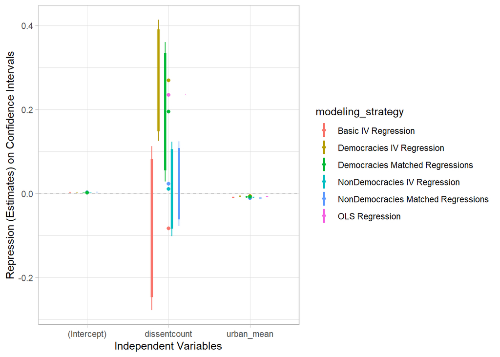

```r
ggplot(Combined_Models,
       aes(x=term,
             y=estimate,
             color=modeling_strategy)) +
  geom_hline(yintercept = 0, color="grey", lty=2) +
  geom_point()+
  geom_linerange(aes(ymin=estimate - 1.96*std.error, ymax=estimate+1.96*std.error), position = position_dodge(width = 1/2))+
  geom_linerange(aes(ymin=estimate-1.65*std.error, ymax=estimate+1.65*std.error), position = position_dodge(width = 1/2),
                 size=1.2)+
  labs(x="Independent Variables",
       y="Repression (Estimates) on Confidence Intervals")+
  theme_light()
```

## Question 3: Extension

### Testing Interactive Relationships

Page 87 of the paper expresses a need for interacting other covariates with dissent to explain how it determines repression as quoted here **Even when it is not directly modeled in empirical analysis, scholars recognize the need to account for dissent and approximate for predictors of dissent in models of repression, including inequality, economic growth, and population size.**

I go on to test the effect of the interactive relationship between population and mobilized dissent on repression. To plot how it determines repression, I hold dissent constant at its minimum and maximum points `(0 and 5 repectively)` as shown in the following code.

### Predicting Fitted Values

```r
#running a linear model of the interaction between popolation and dissent
#I omitt NAs in my dataset because with NAs ggplot will not be able to plot
interactions <- lm(represscount~pop_sum*dissentcount, data = nas_omitted)

range(nas_omitted$pop_sum)#to aid in setting population to millions
```

```
## [1]        0 26480311
```

```r
summary(nas_omitted$dissentcount)#to aid in determining a bandwidth for holding it constant
```

```
##     Min.  1st Qu.   Median     Mean  3rd Qu.     Max.
## 0.000000 0.000000 0.000000 0.003679 0.000000 5.000000
```

```r
#holding dissent constant while allowing population to vary in millions
pre_pred <- data.frame(expand.grid(pop_sum=seq(min(nas_omitted$pop_sum), max(nas_omitted$pop_sum), 1000000),
                                 dissentcount=c(min(nas_omitted$dissentcount),
                                              max(nas_omitted$dissentcount))))

#predicting fitted values
predicted <- predict(interactions,pre_pred, se = T)
#combining the two data frames to have a data frame with fitted values
df_predicted <- cbind(pre_pred, predicted)
```

### Plotting the Interaction

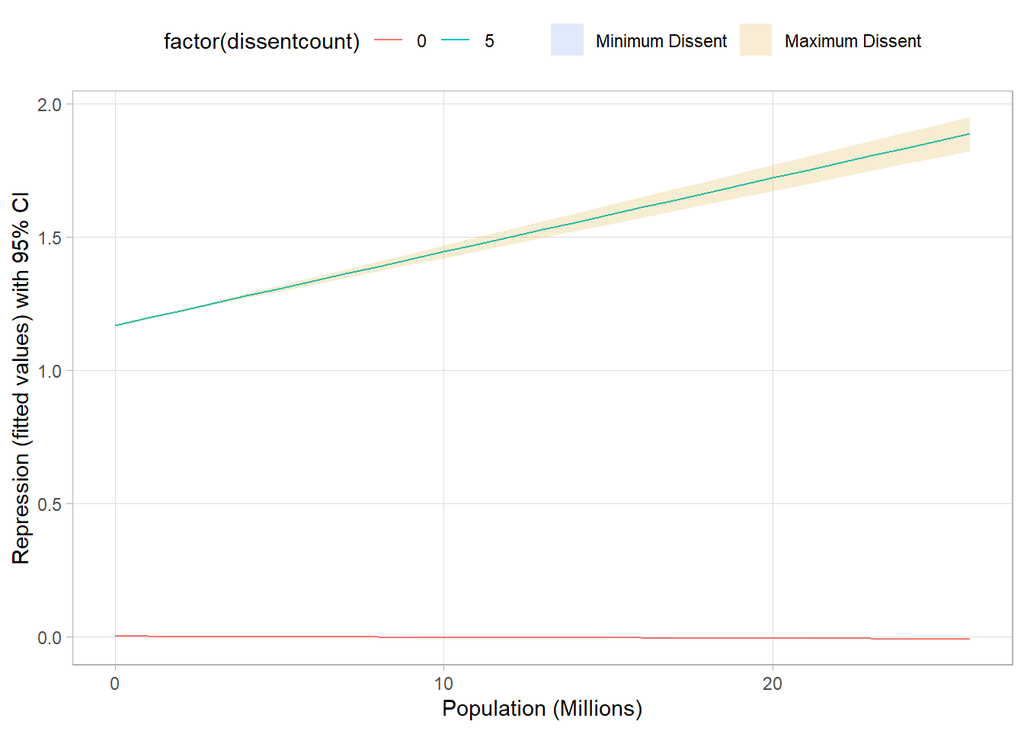

```r
#specifying plotting colors for the confidence intervals
plotcols <-c("cornflowerblue","goldenrod")

#plotting the interactions
ggplot(df_predicted,
       aes(x=pop_sum,
           y=fit,
           color=factor(dissentcount)))+
  geom_line(aes())+
  #specifying the confidence intervals
  geom_ribbon(aes(ymin=fit-1.96*se.fit, ymax=fit+1.96*se.fit, fill=factor(dissentcount)),
              alpha=0.2,
              color=NA)+
  #specifying lables for dissent at points it is held constant
  scale_fill_manual(labels=c("Minimum Dissent",
                             "Maximum Dissent"),
                    name="",
                    values = plotcols)+
  #Naming my x and y axis
  labs(x="Population (Millions)",
       y="Repression (fitted values) with 95% CI")+
  theme_light()+
  #positioning my legend
  theme(legend.position = "top",
        panel.grid.minor = element_blank())+
  #deploying the scales package
  scale_x_continuous(labels = label_number(scale=1/1e6))
```

The plot goes in line with a linear model with such interaction effects, it leads to a positive effect on repression. I show this in the following linear model.

```r
#linear model
all_cov <- lm(represscount~dissentcount+pop_sum+dissentcount*pop_sum, data = rain_data_joined)

stargazer(all_cov, title = "Interaction Effects of Population on Repression", dep.var.labels = "Repression", dep.var.caption = "Dependent Variables",covariate.labels =c("Dissent","Population","Dissent:Population","Constant"), align = TRUE, omit.stat = c("LL","ser","f"), no.space = TRUE, type = "html")
```

**Interaction Effects of Population on Repression**

|  | Dependent Variables |
| --- | --- |
|  | Repression |
| Dissent | 0.230*** |
|  | (0.0003) |
| Population | -0.000*** |
|  | (0.000) |
| Dissent:Population | 0.000*** |
|  | (0.000) |
| Constant | 0.002*** |
|  | (0.00002) |
| Observations | 6,182,064 |
| R<sup>2</sup> | 0.093 |
| Adjusted R<sup>2</sup> | 0.093 |
| *Note:* | p<0.1; p<0.05; p<0.01 |

```r
#interaction estimate b1(Dissent)+b3(population*Dissent)
0.23007576852822+0.00000000559400
```

```
## [1] 0.2300758
```

## Sources

Ritter, Emily H. and Courtenay R. Conrad (2016). Preventing and Responding to Dissent: The Observational Challenges of Explaining Strategic Repression. *American Political Sciences Review*